# Assignment 15

Alejandro Rosales

Section A

## Model Building Activity: Used Car Prices

This activity is designed to have you bring together all of the aspects of building and fitting a multiple regression model to a set of data. For this data set, a representative sample of over eight hundred 2005 General Motors (GM) cars were selected, then retail price was calculated from the tables provided in the 2005 Central Edition of the Kelly Blue Book.

The data file `kuiperCars.csv` contains the following variables:

- `Price` - suggested retail price of the used 2005 GM car in excellent condition. *(The condition of a car can greatly affect price. All cars in this data set were less than one year old when priced and considered to be in excellent condition.)*
- `Mileage` - number of miles the car has been driven
- `Make` - manufacturer of the car such as Saturn, Pontiac, and Chevrolet
- `Model` - specific models for each car manufacturer such as Ion, Vibe, Cavalier
- `Trim` - specific type of car model such as SE Sedan 4D, Quad Coupe 2D
- `Type` - body type such as sedan, coupe, etc.
- `Cylinder` - number of cylinders in the engine
- `Liter` - a more specific measure of engine size
- `Doors` - number of doors
- `Cruise` - 0/1 indicator variable representing whether the car has cruise control (1 = cruise)
- `Sound` - 0/1 indicator variable representing whether the car has upgraded speakers (1 = upgraded)
- `Leather` - 0/1 indicator variable representing whether the car has leather seats (1 = leather)

In the activity, you must take care to consider *and address* all issues and concerns in the development of your model:

- Correctly determine which variable is the response variable and what are the candidate predictor variables.
- Correctly assign the appropriate variable type for each predictor (e.g. which variables are truly categorical here?). Use `mutate` if necessary.
- Perform an effective EDA.
- When fitting models, check and address assumption violations as well as identifying any unusual observations, and deal with them appropriately.
- Perform variable selection (i.e. model selection) to simplify your model.
- Once you are satisfied that you have arrived at a final model, use it to address the two goals stated below.

The following code reads in the data:

```r
cars <- read.csv("kuiperCars.csv")
head(cars)
```

```
##      Price Mileage  Make   Model     Trim  Type Cylinder Liter Doors
## 1 17314.10    8221 Buick Century Sedan 4D Sedan        6   3.1     4
## 2 17542.04    9135 Buick Century Sedan 4D Sedan        6   3.1     4
## 3 16218.85   13196 Buick Century Sedan 4D Sedan        6   3.1     4
## 4 16336.91   16342 Buick Century Sedan 4D Sedan        6   3.1     4
## 5 16339.17   19832 Buick Century Sedan 4D Sedan        6   3.1     4
## 6 15709.05   22236 Buick Century Sedan 4D Sedan        6   3.1     4
##   Cruise Sound Leather
## 1      1     1       1
## 2      1     1       0
## 3      1     1       0
## 4      1     0       0
## 5      1     0       1
## 6      1     1       0
```

**Your goal for this activity** is to develop a good fitting model that can be used to effectively predict the selling price of a 2005 used GM car. More specifically, you need to develop a good model so that you can **answer the following two questions**:

1. Determine what variables are important predictors of the selling price of a car.

Model, Mileage, Trim, Leather, Sound, Cruise

2. Last semester, one of the instructors of this course had a car accident and needed to buy a replacement car. He was looking at a used 2005 Chevrolet Malibu 4-door sedan with 20000 miles, a 6-cylinder 3.5-liter engine, loaded with cruise control, upgraded speakers and leather seats. Use your final model to generate a 95% prediction interval for the price he would have to pay for that car.

Be sure to include your code blocks and write interpretations of the results from the models you generate. *HAVE FUN!*

# Work Below

EDA

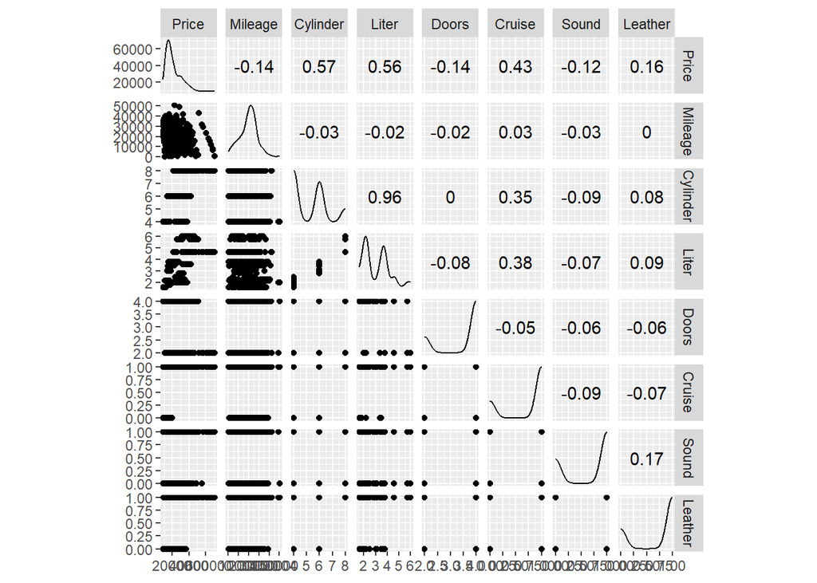

```r
ggscatmat(cars)
```

Variables such as Cruise and Cylinder as well as Liter have a strong moderate affect of the pricing of cars. So well fit a model with just these 3 variables for now and see what happens.

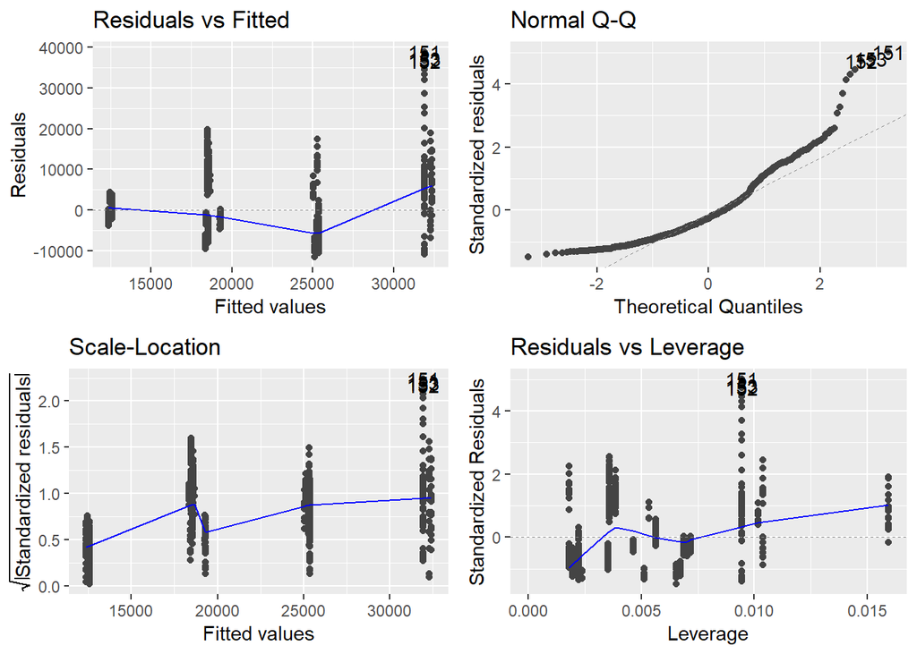

```r
model1 <- lm(Price ~ Cruise + Cylinder + Liter, data=cars)
autoplot(model1)
```

```r
summary(model1)
```

```
##
## Call:
## lm(formula = Price ~ Cruise + Cylinder + Liter, data = cars)
##
## Residuals:
##    Min     1Q Median     3Q    Max
## -11518  -5727  -1958   3682  38833
##
## Coefficients:
##             Estimate Std. Error t value Pr(>|t|)
## (Intercept)   -710.9     1392.9  -0.510    0.610
## Cruise        5963.0      686.2   8.690  < 2e-16 ***
## Cylinder      3141.4      688.8   4.561 5.89e-06 ***
## Liter          334.5      872.9   0.383    0.702
## ---
## Signif. codes:  0 '***' 0.001 '**' 0.01 '*' 0.05 '.' 0.1 ' ' 1
##
## Residual standard error: 7772 on 800 degrees of freedom
## Multiple R-squared:  0.3841, Adjusted R-squared:  0.3818
## F-statistic: 166.3 on 3 and 800 DF,  p-value: < 2.2e-16
```

Varaibles such as Trim accounts for Type and Doors. So we will remove those in this model and keep everything else.

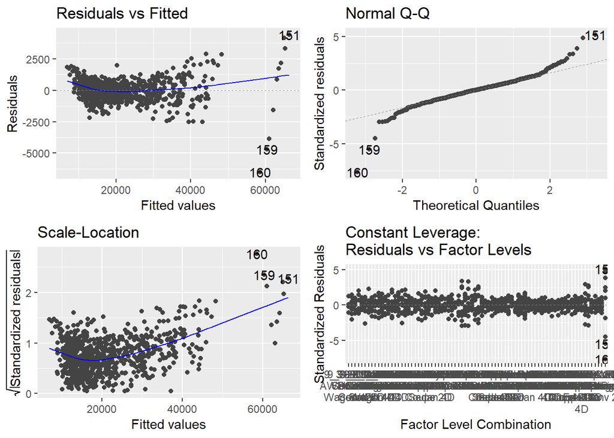

```r
model2 <- lm(Price ~ Cruise + Cylinder + Liter + Mileage + Model + Trim + Sound + Leather, data=cars)
autoplot(model2)
```

```r
summary(model2)
```

```
##
## Call:
## lm(formula = Price ~ Cruise + Cylinder + Liter + Mileage + Model +
##     Trim + Sound + Leather, data = cars)
##
## Residuals:
##     Min      1Q  Median      3Q     Max
## -6523.2  -471.4    18.1   468.9  4425.1
##
## Coefficients: (10 not defined because of singularities)
##                           Estimate Std. Error t value Pr(>|t|)
## (Intercept)              3.141e+04  1.459e+03  21.529  < 2e-16 ***
## Cruise                   6.940e+01  1.015e+02   0.684 0.494443
## Cylinder                 3.146e+03  6.733e+02   4.673 3.53e-06 ***
## Liter                   -4.933e+03  1.435e+03  -3.439 0.000618 ***
## Mileage                 -1.854e-01  4.051e-03 -45.754  < 2e-16 ***
## Model9_3                -4.877e+03  1.065e+03  -4.579 5.50e-06 ***
## Model9_3 HO              1.343e+03  9.838e+02   1.365 0.172786
## Model9_5                 4.260e+03  6.069e+02   7.019 5.12e-12 ***
## Model9_5 HO              4.814e+03  8.340e+02   5.772 1.16e-08 ***
## ModelAVEO               -2.263e+04  1.516e+03 -14.931  < 2e-16 ***
## ModelBonneville         -7.681e+03  1.117e+03  -6.879 1.30e-11 ***
## ModelCavalier           -1.767e+04  9.384e+02 -18.832  < 2e-16 ***
## ModelCentury            -1.580e+04  1.054e+03 -14.993  < 2e-16 ***
## ModelClassic            -1.614e+04  9.794e+02 -16.483  < 2e-16 ***
## ModelCobalt             -1.672e+04  9.318e+02 -17.943  < 2e-16 ***
## ModelCorvette            1.255e+04  2.705e+03   4.639 4.14e-06 ***
## ModelCST-V               1.977e+04  2.317e+03   8.530  < 2e-16 ***
## ModelCTS                -3.402e+03  1.288e+03  -2.640 0.008459 **
## ModelDeville             2.330e+03  1.237e+03   1.884 0.059939 .
## ModelG6                 -1.030e+04  9.591e+02 -10.743  < 2e-16 ***
## ModelGrand Am           -1.518e+04  8.506e+02 -17.848  < 2e-16 ***
## ModelGrand Prix         -1.135e+04  1.107e+03 -10.253  < 2e-16 ***
## ModelGTO                 3.977e+03  2.324e+03   1.712 0.087363 .
## ModelImpala             -1.056e+04  1.086e+03  -9.722  < 2e-16 ***
## ModelIon                -1.660e+04  9.544e+02 -17.396  < 2e-16 ***
## ModelL Series           -1.612e+04  1.049e+03 -15.369  < 2e-16 ***
## ModelLacrosse           -5.483e+03  1.040e+03  -5.271 1.79e-07 ***
## ModelLesabre            -6.824e+03  1.040e+03  -6.559 1.02e-10 ***
## ModelMalibu             -1.374e+04  9.217e+02 -14.908  < 2e-16 ***
```

[output cut: 46 more lines]

```
## TrimSLE Sedan 4D                NA         NA      NA       NA
## TrimSpecial Ed Ultra 4D  1.653e+03  5.687e+02   2.907 0.003764 **
## TrimSportwagon 4D               NA         NA      NA       NA
## TrimSS Coupe 2D          5.413e+03  5.970e+02   9.066  < 2e-16 ***
## TrimSS Sedan 4D          6.183e+03  5.107e+02  12.107  < 2e-16 ***
## TrimSVM Hatchback 4D    -7.948e+02  4.072e+02  -1.952 0.051334 .
## TrimSVM Sedan 4D                NA         NA      NA       NA
## Sound                    2.113e+02  7.976e+01   2.649 0.008257 **
## Leather                  2.954e+02  9.287e+01   3.180 0.001533 **
## ---
## Signif. codes:  0 '***' 0.001 '**' 0.01 '*' 0.05 '.' 0.1 ' ' 1
##
## Residual standard error: 903.3 on 730 degrees of freedom
## Multiple R-squared:  0.9924, Adjusted R-squared:  0.9916
## F-statistic:  1307 on 73 and 730 DF,  p-value: < 2.2e-16
```

The model seems to violate some assumptions. Assumptions such as normality assumption appears to be violated as the right and left sides appear to be lifted from the diagnoal line. The sample size is big so it is not of much concern. There is concern regarding the residuals (linerality) with the pattern forming of sort of a swosh and constant error variance line is not straight and horizontal (large increases in Scale-Location plot).

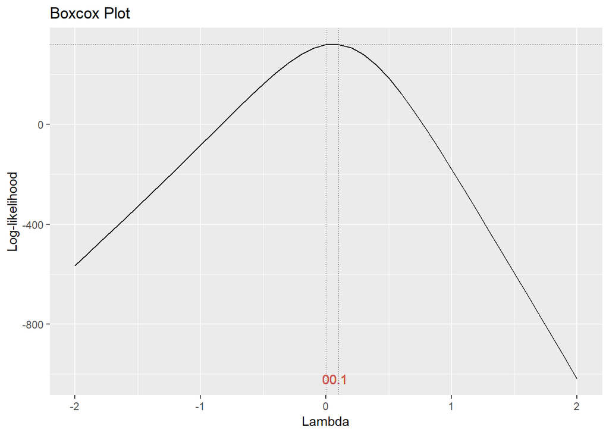

```r
gg_boxcox(model2)
```

Box-cox plot tells us that our model would benefit from a logarithmic transformation. So we will apply it.

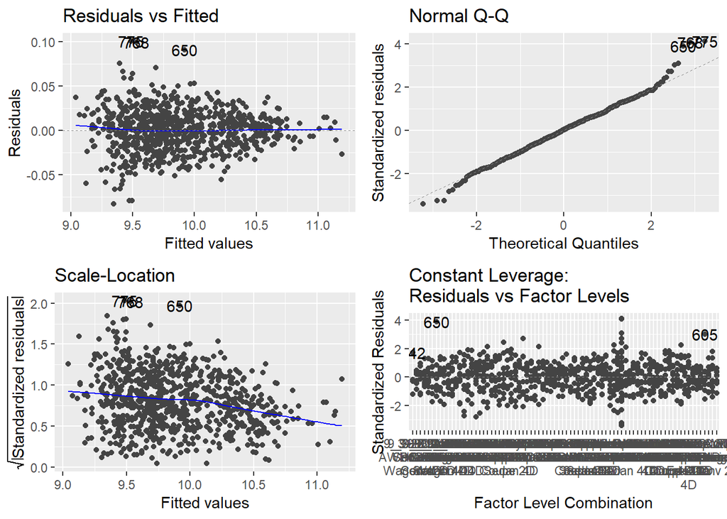

```r
model3 <- lm(log(Price) ~ Cruise + Cylinder + Liter + Mileage + Model + Trim + Sound + Leather, data=cars)
autoplot(model3)
```

```r
summary(model3)
```

```
##
## Call:
## lm(formula = log(Price) ~ Cruise + Cylinder + Liter + Mileage +
##     Model + Trim + Sound + Leather, data = cars)
##
## Residuals:
##       Min        1Q    Median        3Q       Max
## -0.083117 -0.015251  0.000716  0.015175  0.100862
##
## Coefficients: (10 not defined because of singularities)
##                           Estimate Std. Error t value Pr(>|t|)
## (Intercept)              1.033e+01  4.022e-02 256.745  < 2e-16 ***
## Cruise                   5.455e-03  2.799e-03   1.949 0.051697 .
## Cylinder                 1.241e-01  1.856e-02   6.687 4.54e-11 ***
## Liter                   -1.790e-01  3.955e-02  -4.525 7.04e-06 ***
## Mileage                 -8.149e-06  1.117e-07 -72.960  < 2e-16 ***
## Model9_3                -1.589e-01  2.937e-02  -5.410 8.55e-08 ***
## Model9_3 HO              5.695e-02  2.712e-02   2.100 0.036095 *
## Model9_5                 1.566e-01  1.673e-02   9.358  < 2e-16 ***
## Model9_5 HO              1.857e-01  2.299e-02   8.077 2.74e-15 ***
## ModelAVEO               -1.207e+00  4.179e-02 -28.895  < 2e-16 ***
## ModelBonneville         -3.194e-01  3.079e-02 -10.373  < 2e-16 ***
## ModelCavalier           -9.492e-01  2.587e-02 -36.686  < 2e-16 ***
## ModelCentury            -7.735e-01  2.906e-02 -26.618  < 2e-16 ***
## ModelClassic            -8.423e-01  2.700e-02 -31.192  < 2e-16 ***
## ModelCobalt             -8.630e-01  2.569e-02 -33.595  < 2e-16 ***
## ModelCorvette            3.262e-01  7.457e-02   4.375 1.39e-05 ***
## ModelCST-V               4.750e-01  6.389e-02   7.435 2.94e-13 ***
## ModelCTS                -2.103e-01  3.552e-02  -5.920 4.94e-09 ***
## ModelDeville            -3.588e-02  3.410e-02  -1.052 0.293001
## ModelG6                 -5.093e-01  2.644e-02 -19.261  < 2e-16 ***
## ModelGrand Am           -6.804e-01  2.345e-02 -29.011  < 2e-16 ***
## ModelGrand Prix         -5.962e-01  3.052e-02 -19.532  < 2e-16 ***
## ModelGTO                 6.534e-02  6.406e-02   1.020 0.308102
## ModelImpala             -5.523e-01  2.994e-02 -18.450  < 2e-16 ***
## ModelIon                -8.864e-01  2.631e-02 -33.685  < 2e-16 ***
## ModelL Series           -7.026e-01  2.891e-02 -24.302  < 2e-16 ***
## ModelLacrosse           -2.177e-01  2.868e-02  -7.591 9.75e-14 ***
## ModelLesabre            -2.796e-01  2.868e-02  -9.749  < 2e-16 ***
## ModelMalibu             -6.990e-01  2.541e-02 -27.508  < 2e-16 ***
```

[output cut: 46 more lines]

```
## TrimSLE Sedan 4D                NA         NA      NA       NA
## TrimSpecial Ed Ultra 4D  1.412e-01  1.568e-02   9.006  < 2e-16 ***
## TrimSportwagon 4D               NA         NA      NA       NA
## TrimSS Coupe 2D          3.554e-01  1.646e-02  21.589  < 2e-16 ***
## TrimSS Sedan 4D          3.799e-01  1.408e-02  26.985  < 2e-16 ***
## TrimSVM Hatchback 4D     4.650e-03  1.123e-02   0.414 0.678884
## TrimSVM Sedan 4D                NA         NA      NA       NA
## Sound                    6.247e-03  2.199e-03   2.840 0.004630 **
## Leather                  1.758e-02  2.560e-03   6.868 1.40e-11 ***
## ---
## Signif. codes:  0 '***' 0.001 '**' 0.01 '*' 0.05 '.' 0.1 ' ' 1
##
## Residual standard error: 0.0249 on 730 degrees of freedom
## Multiple R-squared:  0.9966, Adjusted R-squared:  0.9963
## F-statistic:  2973 on 73 and 730 DF,  p-value: < 2.2e-16
```

There it looks much better. The Residuals vs Fitted and Scale-location appear more normal now. Now lets look at AIC and BIC of our 3rd model.

```r
AIC(model3)
```

```
## [1] -3583.856
```

```r
BIC(model3)
```

```
## [1] -3232.136
```

Pretty good but I think we can do better. Lets try the stepwise

```r
model.all <- lm(log(Price) ~ Cruise + Cylinder + Liter + Mileage + Model + Trim + Sound + Leather + Type + Doors, data=cars)
null.fit <- lm(log(Price) ~ 1, data=cars)
step.pick.forward <- step(null.fit, scope=formula(model.all), direction="forward")
```

```
## Start:  AIC=-1432.25
## log(Price) ~ 1
##
##            Df Sum of Sq     RSS     AIC
## + Model    31   128.067   6.991 -3750.9
## + Trim     46    82.408  52.650 -2097.7
## + Liter     1    47.079  87.979 -1774.9
## + Cylinder  1    45.947  89.110 -1764.6
## + Type      4    36.259  98.799 -1675.6
## + Cruise    1    32.909 102.149 -1654.8
## + Mileage   1     2.959 132.099 -1448.1
## + Sound     1     2.619 132.439 -1446.0
## + Leather   1     2.285 132.773 -1444.0
## + Doors     1     1.133 133.925 -1437.0
## <none>                  135.058 -1432.3
##
## Step:  AIC=-3750.95
## log(Price) ~ Model
##
##            Df Sum of Sq    RSS     AIC
## + Mileage   1    3.0967 3.8944 -4219.4
## + Trim     38    3.2184 3.7727 -4170.9
## + Type      4    0.8134 6.1777 -3842.4
## + Doors     1    0.2816 6.7095 -3782.0
## + Liter     1    0.1348 6.8563 -3764.6
## + Cylinder  1    0.1294 6.8617 -3764.0
## + Leather   1    0.0371 6.9540 -3753.2
## <none>                  6.9911 -3750.9
## + Sound     1    0.0034 6.9877 -3749.3
## + Cruise    1    0.0018 6.9893 -3749.2
##
## Step:  AIC=-4219.36
## log(Price) ~ Model + Mileage
##
##            Df Sum of Sq    RSS     AIC
## + Trim     38    3.4049 0.4895 -5810.8
## + Type      4    0.9488 2.9457 -4435.8
## + Doors     1    0.3729 3.5215 -4298.3
## + Liter     1    0.1994 3.6950 -4259.6
## + Cylinder  1    0.1902 3.7042 -4257.6
```

[output cut: 19 more lines]

```
## + Cruise  1 0.0025221 0.45777 -5860.7
## <none>                0.46029 -5858.3
##
## Step:  AIC=-5865.34
## log(Price) ~ Model + Mileage + Trim + Leather + Sound
##
##          Df Sum of Sq     RSS     AIC
## + Cruise  1 0.0023556 0.45277 -5867.5
## <none>                0.45512 -5865.3
##
## Step:  AIC=-5867.51
## log(Price) ~ Model + Mileage + Trim + Leather + Sound + Cruise
##
##        Df Sum of Sq     RSS     AIC
## <none>              0.45277 -5867.5
```

```r
summary(step.pick.forward)
```

```
##
## Call:
## lm(formula = log(Price) ~ Model + Mileage + Trim + Leather +
##     Sound + Cruise, data = cars)
##
## Residuals:
##       Min        1Q    Median        3Q       Max
## -0.083117 -0.015251  0.000716  0.015175  0.100862
##
## Coefficients: (8 not defined because of singularities)
##                           Estimate Std. Error t value Pr(>|t|)
## (Intercept)              1.038e+01  2.058e-02 504.134  < 2e-16 ***
## Model9_3                -6.940e-02  2.161e-02  -3.212 0.001377 **
## Model9_3 HO              1.464e-01  1.849e-02   7.921 8.79e-15 ***
## Model9_5                 1.924e-01  1.479e-02  13.004  < 2e-16 ***
## Model9_5 HO              2.215e-01  2.158e-02  10.265  < 2e-16 ***
## ModelAVEO               -1.046e+00  2.171e-02 -48.199  < 2e-16 ***
## ModelBonneville         -3.038e-01  2.159e-02 -14.071  < 2e-16 ***
## ModelCavalier           -8.955e-01  2.299e-02 -38.957  < 2e-16 ***
## ModelCentury            -6.326e-01  2.428e-02 -26.060  < 2e-16 ***
## ModelClassic            -7.886e-01  2.424e-02 -32.525  < 2e-16 ***
## ModelCobalt             -8.093e-01  2.278e-02 -35.524  < 2e-16 ***
## ModelCorvette            1.963e-01  2.466e-02   7.960 6.58e-15 ***
## ModelCST-V               3.988e-01  2.422e-02  16.464  < 2e-16 ***
## ModelCTS                -1.573e-02  2.421e-02  -0.650 0.516096
## ModelDeville             8.477e-02  2.422e-02   3.500 0.000494 ***
## ModelG6                 -4.400e-01  2.397e-02 -18.356  < 2e-16 ***
## ModelGrand Am           -6.267e-01  2.443e-02 -25.657  < 2e-16 ***
## ModelGrand Prix         -5.806e-01  2.403e-02 -24.158  < 2e-16 ***
## ModelGTO                -1.088e-02  2.465e-02  -0.441 0.659163
## ModelImpala             -5.367e-01  2.324e-02 -23.098  < 2e-16 ***
## ModelIon                -8.327e-01  2.346e-02 -35.494  < 2e-16 ***
## ModelL Series           -5.438e-01  2.165e-02 -25.122  < 2e-16 ***
## ModelLacrosse           -2.021e-01  2.161e-02  -9.352  < 2e-16 ***
## ModelLesabre            -2.641e-01  2.164e-02 -12.201  < 2e-16 ***
## ModelMalibu             -6.297e-01  2.283e-02 -27.581  < 2e-16 ***
## ModelMonte Carlo        -5.913e-01  2.476e-02 -23.880  < 2e-16 ***
## ModelPark Avenue        -2.605e-01  2.426e-02 -10.739  < 2e-16 ***
## ModelSTS-V6              2.069e-01  2.422e-02   8.543  < 2e-16 ***
## ModelSTS-V8              3.440e-01  2.422e-02  14.203  < 2e-16 ***
```

[output cut: 44 more lines]

```
## TrimSpecial Ed Ultra 4D  1.412e-01  1.568e-02   9.006  < 2e-16 ***
## TrimSportwagon 4D               NA         NA      NA       NA
## TrimSS Coupe 2D          3.554e-01  1.646e-02  21.589  < 2e-16 ***
## TrimSS Sedan 4D          3.799e-01  1.408e-02  26.985  < 2e-16 ***
## TrimSVM Hatchback 4D     4.650e-03  1.123e-02   0.414 0.678884
## TrimSVM Sedan 4D                NA         NA      NA       NA
## Leather                  1.758e-02  2.560e-03   6.868 1.40e-11 ***
## Sound                    6.247e-03  2.199e-03   2.840 0.004630 **
## Cruise                   5.455e-03  2.799e-03   1.949 0.051697 .
## ---
## Signif. codes:  0 '***' 0.001 '**' 0.01 '*' 0.05 '.' 0.1 ' ' 1
##
## Residual standard error: 0.0249 on 730 degrees of freedom
## Multiple R-squared:  0.9966, Adjusted R-squared:  0.9963
## F-statistic:  2973 on 73 and 730 DF,  p-value: < 2.2e-16
```

This model is the model I choose: lm(formula = log(Price) ~ Model + Mileage + Trim + Leather + Sound + Cruise, data = cars)

```r
model.final = lm(log(Price) ~ Model + Mileage + Trim + Leather + Sound + Cruise, data=cars)
prediction = predict(model.final, newdata=data.frame(Make="Chevrolet", Model="Malibu", Doors=4, Trim="Sedan 4D", Type="Sedan", Mileage=20000, Cylinder=6, Liter=3.5, Cruise=1, Sound=1, Leather=1), int="conf")
print(exp(prediction))
```

```
##        fit      lwr     upr
## 1 16026.41 15841.77 16213.2
```

```r
print(16213.2 - 15841.77)
```

```
## [1] 371.43
```